# Davidson & MacKinnon. Econometric Theory and Methods. (1999)

## Exercise 3.3.

### Using the data on consumption and personal disposable income in Canada for the period 1947 to 1996 in the file consumption.data, estimate the model

$$c_t = \beta_1 + \beta_2y_t+u_t,\ \ \ \ \ u_t\ \sim \ iid\ N(0,\sigma^2) $$

### where $c_t=\log{C_t}$ is the log of consumption and $y_t=\log{Y_t}$ is the log of disposable income, for the entire sample period. Then use the estimates of $\beta_1,\beta_2$, and $\sigma$ to obtain 200 simulated observations on $c_t$. Begin by regressing your simulated log consumption variable on the log of income and a constant using just the first 3 observations. Save the estimates of $\beta_1,\beta_2$, and $\sigma$. Repeat this exercise for sample sizes of $4, 5, ..., 200$. Plot your estimates of $\beta_2$ and $\sigma$ as a function of the sample size. What happens to these estimates as the sample size grows? Repeat the complete exercise with a different set of simulated consumption data. Which features of the paths of the parameter estimates are common to the two experiments, and which are different?

We'll load "consumption.data.txt" provided by the authors in http://qed.econ.queensu.ca/ETM/data/, define the number of simulations $B=200$, and create a vector to fill it when performing the simulations.

```r
#Load consumption.data.txt
data = read.table("consumption.data.txt",col.names=c("n","year","quarter","income", "consumption"))

#Defining number of simulations and creating empty vector to save the results
B = 200
comparison = data.frame("sample_size"=as.integer(),
                        "beta_1_sim1"=as.double(), "beta_2_sim1"=as.double(), "sigma_sim1"=as.double(),
                        "beta_1_sim2"=as.double(), "beta_2_sim2"=as.double(), "sigma_sim2"=as.double())
```

Then, we will perform a linear regression to get the estimates $\beta_1$ and $\beta_2$, and get its $\sigma$ of the original data set.

```r
#Running regression to get the estimates and sigma of the original data set
reg = lm(log(consumption) ~ log(income), data) ; summary(reg)
coeff = reg$coefficients
beta_1 = coeff["(Intercept)"]
beta_2 = coeff["log(income)"]
sigma = summary(reg)$sigma
```

```
Call:
lm(formula = log(consumption) ~ log(income), data = data)

Residuals:
      Min        1Q    Median        3Q       Max
-0.113024 -0.026878  0.008358  0.025481  0.090263

Coefficients:
            Estimate Std. Error t value Pr(>|t|)
(Intercept) 0.417736   0.048988   8.527 3.84e-15 ***
log(income) 0.956939   0.004046 236.543  < 2e-16 ***
---
Signif. codes:  0 '***' 0.001 '**' 0.01 '*' 0.05 '.' 0.1 ' ' 1

Residual standard error: 0.03581 on 198 degrees of freedom
Multiple R-squared:  0.9965,	Adjusted R-squared:  0.9965
F-statistic: 5.595e+04 on 1 and 198 DF,  p-value: < 2.2e-16
```

First, we will perform a parametric bootstrap to generate the first simulated data set, then we will perform 198 regressions from with number of observations from 3 to 200 and save the estimates into an empty vector.

```r
#First Simulation - Simulation by original observations order
#Parametric Bootstrap - considering the residuals have normal distribution with mean 0
set.seed(4321)
residual_boot = rnorm(B, 0, sd = sigma)
X = cbind(1, log(data$income))

log_consumption_sim1 = X %*% coeff + residual_boot

data_sim1 = data.frame("log_consumption_sim1" = log_consumption_sim1, "log_income" = log(data$income))

for (i in 3:B){
  reg = lm(log_consumption_sim1[1:i] ~ log_income[1:i], data_sim1) #; summary(reg)
  coeff_sim1 = summary(reg)$coefficients

  #Saving the regression estimates and standard deviation
  comparison[i-2,"sample_size"] = i
  comparison[i-2,"beta_1_sim1"] = coeff_sim1["(Intercept)", "Estimate"]
  comparison[i-2,"beta_2_sim1"] = coeff_sim1["log_income[1:i]", "Estimate"]
  comparison[i-2,"sigma_sim1"] = summary(reg)$sigma
}
```

For the the second simulation, we will replicate the same method done for the first simulation.

```r
#Second Simulation
set.seed(1234)
residual_boot = rnorm(B, 0, sd = sigma)

log_consumption_sim2 = X %*% coeff + residual_boot

data_sim2 = data.frame("log_consumption_sim2" = log_consumption_sim2, "log_income" = log(data$income))
i=3
for (i in 3:B){
  reg = lm(log_consumption_sim2[1:i] ~ log_income[1:i], data_sim2) #; summary(reg)
  coeff_sim2 = summary(reg)$coefficients

  #Saving the regression estimates and standard deviation
  #comparison[i-2,"sample_size"] = i
  comparison[i-2,"beta_1_sim2"] = coeff_sim2["(Intercept)", "Estimate"]
  comparison[i-2,"beta_2_sim2"] = coeff_sim2["log_income[1:i]", "Estimate"]
  comparison[i-2,"sigma_sim2"] = summary(reg)$sigma
}
```

```r
cat("First 6 lines\n")
print(head(cbind("size"=comparison$sample_size,
        "beta1_sim1"=round(comparison$beta_1_sim1,4), "beta2_sim1"=round(comparison$beta_2_sim1,5), "sigma_sim1"=round(comparison$sigma_sim1,6),
        "beta1_sim2"=round(comparison$beta_1_sim2,4), "beta2_sim2"=round(comparison$beta_2_sim2,5), "sigma_sim2"=round(comparison$sigma_sim2,6))))

cat("\nLast 6 lines\n")
print(tail(cbind("size"=comparison$sample_size,
         "beta1_sim1"=round(comparison$beta_1_sim1,4), "beta2_sim1"=round(comparison$beta_2_sim1,5), "sigma_sim1"=round(comparison$sigma_sim1,6),
         "beta1_sim2"=round(comparison$beta_1_sim2,4), "beta2_sim2"=round(comparison$beta_2_sim2,5), "sigma_sim2"=round(comparison$sigma_sim2,6))))
```

```
First 6 lines
     size beta1_sim1 beta2_sim1 sigma_sim1 beta1_sim2 beta2_sim2 sigma_sim2
[1,]    3    36.9484   -2.36626   0.014192    42.5534   -2.87607   0.049605
[2,]    4    -5.8564    1.52804   0.025794    31.0806   -1.83229   0.035649
[3,]    5    -3.9142    1.35117   0.023003    24.3908   -1.22308   0.043157
[4,]    6    -6.3367    1.57209   0.030127    22.3771   -1.03944   0.041831
[5,]    7     1.2087    0.88606   0.030031    13.4585   -0.22856   0.040564
[6,]    8     1.3717    0.87124   0.027419    10.6110    0.03032   0.037965

Last 6 lines
       size beta1_sim1 beta2_sim1 sigma_sim1 beta1_sim2 beta2_sim2 sigma_sim2
[193,]  195     0.4797    0.95193   0.033065     0.2922    0.96719   0.036030
[194,]  196     0.4831    0.95164   0.033039     0.2908    0.96731   0.035947
[195,]  197     0.4817    0.95176   0.032965     0.2889    0.96747   0.035872
[196,]  198     0.4778    0.95210   0.032965     0.2938    0.96705   0.035900
[197,]  199     0.4764    0.95222   0.032892     0.2938    0.96705   0.035809
[198,]  200     0.4687    0.95288   0.033143     0.3031    0.96625   0.036169
```

Then, we'll plot $\beta_2$ estimates by the number of observations in the regression for Simulation 1 (black), Simulation 2 (blue) and a horizontal dotted orange line with the exact value. We can see that, in both simulations, the estimates get close to the actual value with regressions starting with 40 to 50 observations.

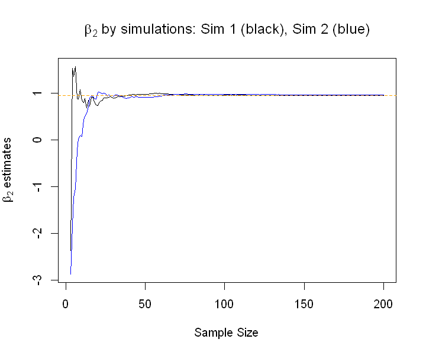

```r
options(warn=-1)
options(repr.plot.width=6, repr.plot.height=5)
plot(comparison$sample_size, comparison$beta_2_sim1, type="line",
     ylim=c(min(comparison$beta_2_sim1,comparison$beta_2_sim2), max(comparison$beta_2_sim1,comparison$beta_2_sim2)),
     main=expression(beta[2]~"by simulations: Sim 1 (black), Sim 2 (blue)"),
     xlab = "Sample Size", ylab=expression(beta[2]~"estimates"))
lines(comparison$sample_size, comparison$beta_2_sim2, col="blue")
abline(h = beta_2, col="orange", lty=2)
```

For the standard deviation, we can see that the second simulation gets close to the actual value within regression with 60 observations, then move away a little and converges when regresion uses almost all 200 observatins. $$$$ The first simulation gets more or less close with regression with 100 observations but didn't converge to the actual standard deviation even with regressions with all 200 observations.

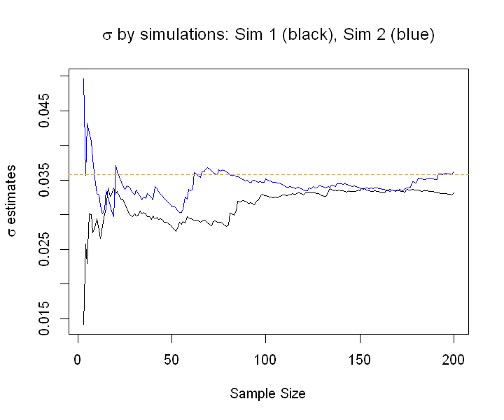

```r
options(repr.plot.width=6, repr.plot.height=5)
plot(comparison$sample_size, comparison$sigma_sim1, type="line",
     ylim=c(min(comparison$sigma_sim1,comparison$sigma_sim2), max(comparison$sigma_sim1,comparison$sigma_sim2)),
     main=expression(sigma~"by simulations: Sim 1 (black), Sim 2 (blue)"),
     xlab = "Sample Size", ylab=expression(sigma~"estimates"))
lines(comparison$sample_size, comparison$sigma_sim2, col="blue")
abline(h = sigma, col="orange", lty=2)
options(warn=0)
```

Note that, the estimates vary wildly at the beginning and then settle down, although $\sigma$ estimates settle down less quickly than did the estimates of $\beta_2$. The reason for this is that $y_t$ is a trending variable. This contradicts assumption (3.17), used in Section 3.4 when discussed the rate of convergence of $\hat\beta$. $$$$ As a consequence, $\sum^n_{t=1} y^2_t$ grows at a rate much faster than $n-1$, and $\hat\beta_2$ therefore converges at a rate considerably faster than $n^{−1/2}$.